# *PrescRiptions Report - July 2019*

Authors: *Cristina Muschitiello* - *Niccolò Stamboglis*

**e-Rum2020** - 20th June 2020

*** 7 June 2020***

This document is automatically generated using the package **PrescRiptions**. It is composed of the following sections:

- **Report By Region**: *England - July 2019* : Summary section for the Region.

NO CUSTOMISED PARAMETERS HAVE BEEN SELECTED FOR THIS REPORT

**All the analyses have been run on SAMPLE PLPD DATA (500.000 ROWS). For complete data data, set** *sample = FALSE* **in the** *monthlyDataImport()* **function**.

——————————————————————————————————————————————————————————

# *Report by Region*

*England - July 2019*

## **Summary**

In England during July 2019 the following numbers were registered:

Region Numbers

| ITEMS | 5.418.511 |
| --- | --- |
| NIC | 40.658.504 |
| ACT.COST | 38.007.587 |
| QUANTITY | 385.112.184 |

## **Analysis by BNF Code**

### *Summary table*

The information on prescription at *England-July 2019* level by BNF chapter are summarised in the following table

England - July 2019 by BNF Chapter

| BNF.Chapter | ITEMS | NIC | ACT.COST | QUANTITY |
| --- | --- | --- | --- | --- |
| Anaesthesia | 8.688 | 154.149,8 | 143.476,0 | 130.883 |
| Appliances | 125.984 | 1.905.981,6 | 1.773.271,7 | 12.413.242 |
| Cardiovascular System | 1.596.980 | 6.405.373,1 | 6.005.127,7 | 54.442.794 |
| Central Nervous System | 1.149.862 | 6.699.970,5 | 6.292.406,1 | 79.180.412 |
| Dressings | 37.172 | 801.798,3 | 745.584,4 | 906.819 |
| Ear, Nose And Oropharynx | 52.457 | 338.178,5 | 315.013,7 | 812.273 |
| Endocrine System | 511.312 | 5.997.043,8 | 5.591.594,2 | 23.916.900 |
| Eye | 79.370 | 694.736,1 | 646.830,4 | 1.035.751 |
| Gastro-Intestinal System | 532.127 | 2.412.470,9 | 2.264.010,3 | 40.638.302 |
| Immunological Products & Vaccines | 8.549 | 135.189,1 | 125.670,1 | 8.616 |
| Incontinence Appliances | 10.975 | 267.773,2 | 249.346,3 | 215.220 |
| Infections | 162.196 | 847.712,6 | 793.909,5 | 6.210.111 |
| Malignant Disease & Immunosuppression | 21.127 | 685.851,4 | 638.469,9 | 807.520 |
| Musculoskeletal & Joint Diseases | 148.218 | 1.070.390,1 | 1.000.558,6 | 9.813.181 |
| Nutrition And Blood | 283.781 | 2.620.387,0 | 2.459.051,6 | 112.375.058 |
| Obstetrics,Gynae+Urinary Tract Disorders | 144.777 | 1.461.769,7 | 1.364.939,3 | 6.439.728 |
| Other Drugs And Preparations | 5.081 | 139.707,6 | 130.140,2 | 2.984.557 |
| Respiratory System | 370.548 | 5.020.983,0 | 4.676.175,6 | 7.568.895 |
| Skin | 137.110 | 1.279.330,1 | 1.192.254,0 | 24.463.004 |
| Stoma Appliances | 32.197 | 1.719.707,7 | 1.599.757,7 | 748.918 |

### *Prescribed items*

**Prescribed items by BNF code** for *England-July 2019* are distributed as follows

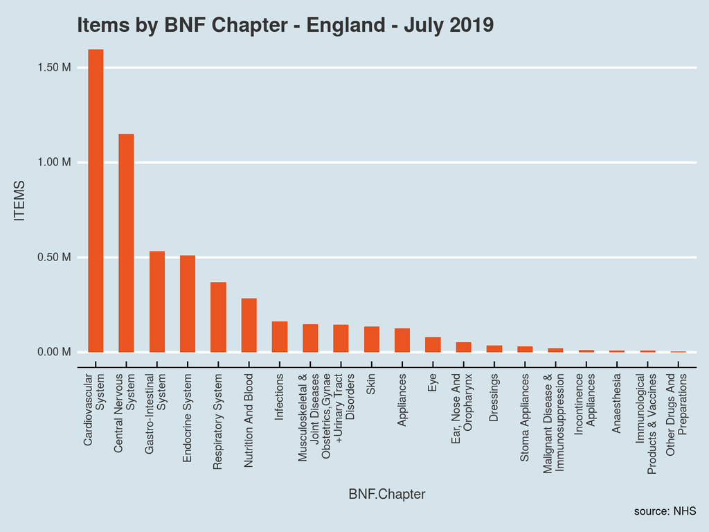

### *Actual Costs*

**Actual costs by BNF code** for *England-July 2019* are distributed by BNF code as follows

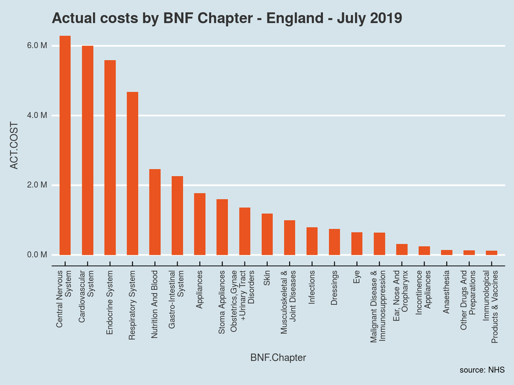

### *Prescribed quantity*

**Total prescribed quantity by BNF code** for *England-July 2019* are distributed by BNF code as follows

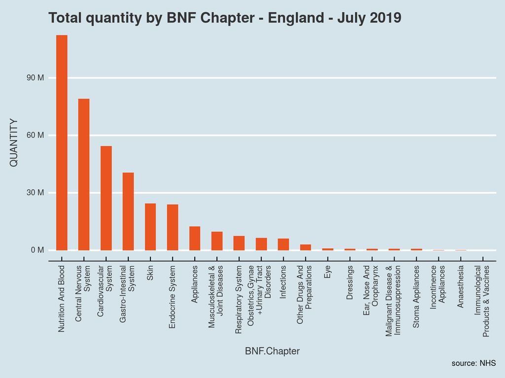

## **Costs summary by CCG**

This section analyses Net Ingredient Costs per 1K patients in *England-July 2019*. Cost analysis might be useful to the NHS for cost-containment. The figure below provides a graphical representation of Costs by CCG.

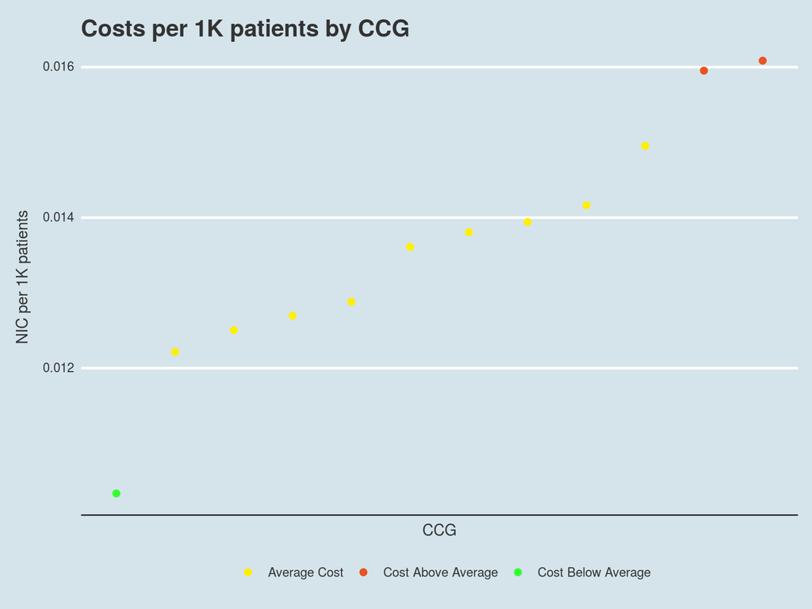

## **Costlier GPs**

Below the list of practices who were in the higher end of the distribution of Net Ingredient Cost per 1K patients is reported. More specifically, the table reports the practices with highest NIC per 1K patients, as identified by the practices having a z-score for NIC per 1K patients higher than 2.

The practices reported in the table are the ones which should be considered as reporting an higher-than usual cost per 1K patients. These are practices which should be carefully considered to understand the reasons for their high per capita costs.

COSTLIER PRACTICES - England - July 2019

| PRACTICE | ITEMS | NIC | ACT.COST | QUANTITY | NUMBER_OF_PATIENTS | NIC_RATE |
| --- | --- | --- | --- | --- | --- | --- |
| Y02045 | 1.323 | 26.411,51 | 24.584,49 | 128.636,7 | 5 | 5,28 |

——————————————————————————————————————————————————————————

# Data source

Information on prescriptions have been obtained from NHS. Additional information on prescriptions can be found at this website https://digital.nhs.uk/data-and-information/publications/statistical/practice-level-prescribing-data.

All information are made available via the PrescRiption package.